# Personal Information

Name: **Merle van Hellemondt**

StudentID: **13759620**

Email: **merle.van.hellemondt@student.uva.nl**

Submitted on: **23.03.2026**

GitHub link: https://github.com/Merle16/Thesis-DS.git

# Data Context

**The dataset used for this thesis originates from Kaggle. The dataset contains various variables, including lifestyle and medical data. The dataset consist of 35 features, and 2149 entries. The target variable is the Diagnosis variable, which is a binary variable where 1 refers to the patient having Alzheimer's Disease and 0 referring to the patient not having Alzheimer's disease. Further information and the EDA will be explained below.**

# Data Description

**In this Exploratory Data Analysis (EDA) several things have become clear concerning the structure and completeness of the data. First of all, the EDA points out that the overall data quality is quite high. The dataset consist of 35 variables and 2149 entries. The gender is distributed as follows: about 51% of the population is female and 49% is male, indicating a balanced representation**

Furthermore, the corpus level analysis points out that there are no null-values found in any of the columns. Furthermore, potential duplicates in PatientID have been checked, as this would be disrupting for the rest of the research. No duplicate PatientID's have been found, which is a positive. The datatypes have been checked, and boxplots have been generated to detect potential outliers. One noticable finding, is that the final column, namely DoctorInCharge, is blanked out due to privacy reasons. Therefore, the column DoctorInCarge has been removed from the dataset.

**Univariate Analysis**

The Univariate Analysis shows an interesting finding. Quite some of the variables are measured on a ordinal bounded scale (0-10 e.g.). This is not something to be resolved in the EDA. However, this is an important finding for the model development stage of this research, as this may affect model performance and behavior. Furthermore the distribution of age has been checked, as this might be an important variable for the Alzheimer's Disease detection. The distribution is listed below:

[figure not shown]

As visible in the graph above, the age is quite evenly distributed and ranges from 60-90. Considering Alzheimer's Disease typically develops mid-60s or later, this range makes sense.

**Numerical Variables and Diagnosis**

[figure not shown]

A clear difference is observed in MMSE scores between diagnosed and non-diagnosed patients. Individuals diagnosed with Alzheimer’s disease show notably lower MMSE scores compared to those without a diagnosis. This indicates that MMSE is strongly associated with cognitive impairment and serves as a key predictor for Alzheimer’s disease. Additionally, the distribution of individual observations further highlights the concentration of lower scores within the diagnosed group, reinforcing the strong predictive potential of MMSE.

The same boxplots have been generated for the variables BMI, Age, and PhysicalActivity. The results of these are that the boxplots are very similar, meaning they are individually weak predictors. However, the combination of several features might increase predictive performance, and therefore they are still considered in further research.

**Medical and Lifestyle variables**

Additionally, more boxplots where generated for both lifestyle and medical variables seperately. In addition to MMSE, functional assessment and activities of daily living (ADL) scores show a clear distinction between diagnosed and non-diagnosed patients. Individuals with Alzheimer’s disease exhibit notably lower scores on both measures, indicating reduced functional and daily living capabilities. The distributions of these variables show a clear shift between the two groups, with less overlap compared to lifestyle variables. This suggests that functional and cognitive measures have strong discriminative power and are likely to be key predictors in the modeling phase. The corresponding boxplots are displayed below:

[figure not shown]

**Categorical Variables Analysis**

Finally, the analysis of categorical variables shows only minor differences in Alzheimer’s diagnosis rates across groups. It is presented below:

[figure not shown]

Variables such as diabetes, smoking, and family history show similar proportions of diagnosed people. This indicates they are weak predictors for the target variable. From the four variables plotted, the hypertension variable is the most telling one, but still the impact seems to remain limited. Overall, the categorical medical and lifestyle variables have lower discriminative power compared to the cognitive and functional variables. ]

**Multivariate Analysis**

For the multivariate analysis the correlation between the target variable and all other variables is investigated. The figure below shows the results:

[figure not shown]

As already became clear from the previous results, the variables MMSE, Functional Assessment, and ADL have a strong negative correlation with the target variable. This indicates that lower scores of these variables lead to a higher likelihood of being diagnosed with Alzheimer's. On the other hand, the strongest positive correlation is the memory complaints and behavioral problems. We can therefore conclude that the higher the memory complaints or the higher the behavioral problems, the higher the likelihood of the Alzheimer's diagnosis is.

**Key EDA Findings and Implications**

Overall, the EDA has revealed that cognitive and functional variables, and more particularly MMSE, Functional Assesssment, and ADL, have strong predictive potential for the Alzheimer's diagnosis prediction. Compared to the functional and cognitive variables, the lifestyle and demographic variables seem to have limited individual predictive power. These findings suggest that a model trained on cognitive and functional variables is likely to outperform a model trained solely on lifestyle features. However, an important nuance in this context is that the EDA only reveals individual predictive power to the target variable, and the combination of variables might be a stronger predictor. However, this is something to investigate further in the modelling phase, but is important to note.

# Imports

```python
import os
import numpy as np
import pandas as pd

import os
os.getcwd()
```

```
'/Users/merlevanhellemondt/Desktop/IS Data Science/Thesis/Thesis-DS/notebooks'
```

# Load your data here

```python
df = pd.read_csv("../data/alzheimers_disease_data.csv")
df.head()
```

|  | PatientID | Age | Gender | Ethnicity | EducationLevel | BMI | Smoking | AlcoholConsumption | PhysicalActivity | DietQuality | ... | MemoryComplaints | BehavioralProblems | ADL | Confusion | Disorientation | PersonalityChanges | DifficultyCompletingTasks | Forgetfulness | Diagnosis | DoctorInCharge |
| --- | --- | --- | --- | --- | --- | --- | --- | --- | --- | --- | --- | --- | --- | --- | --- | --- | --- | --- | --- | --- | --- |
| 0 | 4751 | 73 | 0 | 0 | 2 | 22.927749 | 0 | 13.297218 | 6.327112 | 1.347214 | ... | 0 | 0 | 1.725883 | 0 | 0 | 0 | 1 | 0 | 0 | XXXConfid |
| 1 | 4752 | 89 | 0 | 0 | 0 | 26.827681 | 0 | 4.542524 | 7.619885 | 0.518767 | ... | 0 | 0 | 2.592424 | 0 | 0 | 0 | 0 | 1 | 0 | XXXConfid |
| 2 | 4753 | 73 | 0 | 3 | 1 | 17.795882 | 0 | 19.555085 | 7.844988 | 1.826335 | ... | 0 | 0 | 7.119548 | 0 | 1 | 0 | 1 | 0 | 0 | XXXConfid |
| 3 | 4754 | 74 | 1 | 0 | 1 | 33.800817 | 1 | 12.209266 | 8.428001 | 7.435604 | ... | 0 | 1 | 6.481226 | 0 | 0 | 0 | 0 | 0 | 0 | XXXConfid |
| 4 | 4755 | 89 | 0 | 0 | 0 | 20.716974 | 0 | 18.454356 | 6.310461 | 0.795498 | ... | 0 | 0 | 0.014691 | 0 | 0 | 1 | 1 | 0 | 0 | XXXConfid |

5 rows × 35 columns

### Analysis 1:

Make sure to add some explanation of what you are doing in your code. This will help you and whoever will read this a lot in following your steps.

```python
# Corpus level orientation
df.shape
df.info()
df.isnull().sum()
```

```
<class 'pandas.core.frame.DataFrame'>
RangeIndex: 2149 entries, 0 to 2148
Data columns (total 35 columns):
 #   Column                     Non-Null Count  Dtype
---  ------                     --------------  -----
 0   PatientID                  2149 non-null   int64
 1   Age                        2149 non-null   int64
 2   Gender                     2149 non-null   int64
 3   Ethnicity                  2149 non-null   int64
 4   EducationLevel             2149 non-null   int64
 5   BMI                        2149 non-null   float64
 6   Smoking                    2149 non-null   int64
 7   AlcoholConsumption         2149 non-null   float64
 8   PhysicalActivity           2149 non-null   float64
 9   DietQuality                2149 non-null   float64
```

[output cut: 27 more lines]

```
PatientID                    0
Age                          0
Gender                       0
Ethnicity                    0
EducationLevel               0
BMI                          0
Smoking                      0
AlcoholConsumption           0
PhysicalActivity             0
DietQuality                  0
SleepQuality                 0
FamilyHistoryAlzheimers      0
CardiovascularDisease        0
Diabetes                     0
Depression                   0
HeadInjury                   0
Hypertension                 0
SystolicBP                   0
DiastolicBP                  0
CholesterolTotal             0
CholesterolLDL               0
CholesterolHDL               0
CholesterolTriglycerides     0
MMSE                         0
FunctionalAssessment         0
MemoryComplaints             0
BehavioralProblems           0
ADL                          0
Confusion                    0
Disorientation               0
PersonalityChanges           0
DifficultyCompletingTasks    0
Forgetfulness                0
Diagnosis                    0
DoctorInCharge               0
dtype: int64
```

### Analysis 2:

```python
#Data cleaning & pre-variable
df.shape
df.info()
```

```
<class 'pandas.core.frame.DataFrame'>
RangeIndex: 2149 entries, 0 to 2148
Data columns (total 35 columns):
 #   Column                     Non-Null Count  Dtype
---  ------                     --------------  -----
 0   PatientID                  2149 non-null   int64
 1   Age                        2149 non-null   int64
 2   Gender                     2149 non-null   int64
 3   Ethnicity                  2149 non-null   int64
 4   EducationLevel             2149 non-null   int64
 5   BMI                        2149 non-null   float64
 6   Smoking                    2149 non-null   int64
 7   AlcoholConsumption         2149 non-null   float64
 8   PhysicalActivity           2149 non-null   float64
 9   DietQuality                2149 non-null   float64
```

[output cut: 27 more lines]

```python
#missing values
df.isnull().sum()
```

```
PatientID                    0
Age                          0
Gender                       0
Ethnicity                    0
EducationLevel               0
BMI                          0
Smoking                      0
AlcoholConsumption           0
PhysicalActivity             0
DietQuality                  0
SleepQuality                 0
FamilyHistoryAlzheimers      0
CardiovascularDisease        0
Diabetes                     0
Depression                   0
HeadInjury                   0
Hypertension                 0
SystolicBP                   0
DiastolicBP                  0
CholesterolTotal             0
CholesterolLDL               0
CholesterolHDL               0
CholesterolTriglycerides     0
MMSE                         0
FunctionalAssessment         0
MemoryComplaints             0
BehavioralProblems           0
ADL                          0
Confusion                    0
Disorientation               0
PersonalityChanges           0
DifficultyCompletingTasks    0
Forgetfulness                0
Diagnosis                    0
DoctorInCharge               0
dtype: int64
```

```python
#check duplicate ID's
df.duplicated().sum()
df['PatientID'].duplicated().sum()
```

```
np.int64(0)
```

```python
#check datatypes
df.dtypes
```

```
PatientID                      int64
Age                            int64
Gender                         int64
Ethnicity                      int64
EducationLevel                 int64
BMI                          float64
Smoking                        int64
AlcoholConsumption           float64
PhysicalActivity             float64
DietQuality                  float64
SleepQuality                 float64
FamilyHistoryAlzheimers        int64
CardiovascularDisease          int64
Diabetes                       int64
Depression                     int64
HeadInjury                     int64
Hypertension                   int64
SystolicBP                     int64
DiastolicBP                    int64
CholesterolTotal             float64
CholesterolLDL               float64
CholesterolHDL               float64
CholesterolTriglycerides     float64
MMSE                         float64
FunctionalAssessment         float64
MemoryComplaints               int64
BehavioralProblems             int64
ADL                          float64
Confusion                      int64
Disorientation                 int64
PersonalityChanges             int64
DifficultyCompletingTasks      int64
Forgetfulness                  int64
Diagnosis                      int64
DoctorInCharge                object
dtype: object
```

```python
#verify the ranges
print("Age:", df['Age'].min(), df['Age'].max())
print("BMI:", df['BMI'].min(), df['BMI'].max())
print("MMSE:", df['MMSE'].min(), df['MMSE'].max())
```

```
Age: 60 90
BMI: 15.00885118163106 39.99276746402374
MMSE: 0.0053121464417005 29.991380560529063
```

```python
#Drop the doctor column
df.drop(columns=["DoctorInCharge"], inplace=True)
df.head()
```

|  | PatientID | Age | Gender | Ethnicity | EducationLevel | BMI | Smoking | AlcoholConsumption | PhysicalActivity | DietQuality | ... | FunctionalAssessment | MemoryComplaints | BehavioralProblems | ADL | Confusion | Disorientation | PersonalityChanges | DifficultyCompletingTasks | Forgetfulness | Diagnosis |
| --- | --- | --- | --- | --- | --- | --- | --- | --- | --- | --- | --- | --- | --- | --- | --- | --- | --- | --- | --- | --- | --- |
| 0 | 4751 | 73 | 0 | 0 | 2 | 22.927749 | 0 | 13.297218 | 6.327112 | 1.347214 | ... | 6.518877 | 0 | 0 | 1.725883 | 0 | 0 | 0 | 1 | 0 | 0 |
| 1 | 4752 | 89 | 0 | 0 | 0 | 26.827681 | 0 | 4.542524 | 7.619885 | 0.518767 | ... | 7.118696 | 0 | 0 | 2.592424 | 0 | 0 | 0 | 0 | 1 | 0 |
| 2 | 4753 | 73 | 0 | 3 | 1 | 17.795882 | 0 | 19.555085 | 7.844988 | 1.826335 | ... | 5.895077 | 0 | 0 | 7.119548 | 0 | 1 | 0 | 1 | 0 | 0 |
| 3 | 4754 | 74 | 1 | 0 | 1 | 33.800817 | 1 | 12.209266 | 8.428001 | 7.435604 | ... | 8.965106 | 0 | 1 | 6.481226 | 0 | 0 | 0 | 0 | 0 | 0 |
| 4 | 4755 | 89 | 0 | 0 | 0 | 20.716974 | 0 | 18.454356 | 6.310461 | 0.795498 | ... | 6.045039 | 0 | 0 | 0.014691 | 0 | 0 | 1 | 1 | 0 | 0 |

5 rows × 34 columns

### Analysis 3:

```python
#Univariate analysis
df.describe()
```

|  | PatientID | Age | Gender | Ethnicity | EducationLevel | BMI | Smoking | AlcoholConsumption | PhysicalActivity | DietQuality | ... | FunctionalAssessment | MemoryComplaints | BehavioralProblems | ADL | Confusion | Disorientation | PersonalityChanges | DifficultyCompletingTasks | Forgetfulness | Diagnosis |
| --- | --- | --- | --- | --- | --- | --- | --- | --- | --- | --- | --- | --- | --- | --- | --- | --- | --- | --- | --- | --- | --- |
| count | 2149.000000 | 2149.000000 | 2149.000000 | 2149.000000 | 2149.000000 | 2149.000000 | 2149.000000 | 2149.000000 | 2149.000000 | 2149.000000 | ... | 2149.000000 | 2149.000000 | 2149.000000 | 2149.000000 | 2149.000000 | 2149.000000 | 2149.000000 | 2149.000000 | 2149.000000 | 2149.000000 |
| mean | 5825.000000 | 74.908795 | 0.506282 | 0.697534 | 1.286645 | 27.655697 | 0.288506 | 10.039442 | 4.920202 | 4.993138 | ... | 5.080055 | 0.208004 | 0.156817 | 4.982958 | 0.205212 | 0.158213 | 0.150768 | 0.158678 | 0.301536 | 0.353653 |
| std | 620.507185 | 8.990221 | 0.500077 | 0.996128 | 0.904527 | 7.217438 | 0.453173 | 5.757910 | 2.857191 | 2.909055 | ... | 2.892743 | 0.405974 | 0.363713 | 2.949775 | 0.403950 | 0.365026 | 0.357906 | 0.365461 | 0.459032 | 0.478214 |
| min | 4751.000000 | 60.000000 | 0.000000 | 0.000000 | 0.000000 | 15.008851 | 0.000000 | 0.002003 | 0.003616 | 0.009385 | ... | 0.000460 | 0.000000 | 0.000000 | 0.001288 | 0.000000 | 0.000000 | 0.000000 | 0.000000 | 0.000000 | 0.000000 |
| 25% | 5288.000000 | 67.000000 | 0.000000 | 0.000000 | 1.000000 | 21.611408 | 0.000000 | 5.139810 | 2.570626 | 2.458455 | ... | 2.566281 | 0.000000 | 0.000000 | 2.342836 | 0.000000 | 0.000000 | 0.000000 | 0.000000 | 0.000000 | 0.000000 |
| 50% | 5825.000000 | 75.000000 | 1.000000 | 0.000000 | 1.000000 | 27.823924 | 0.000000 | 9.934412 | 4.766424 | 5.076087 | ... | 5.094439 | 0.000000 | 0.000000 | 5.038973 | 0.000000 | 0.000000 | 0.000000 | 0.000000 | 0.000000 | 0.000000 |
| 75% | 6362.000000 | 83.000000 | 1.000000 | 1.000000 | 2.000000 | 33.869778 | 1.000000 | 15.157931 | 7.427899 | 7.558625 | ... | 7.546981 | 0.000000 | 0.000000 | 7.581490 | 0.000000 | 0.000000 | 0.000000 | 0.000000 | 1.000000 | 1.000000 |
| max | 6899.000000 | 90.000000 | 1.000000 | 3.000000 | 3.000000 | 39.992767 | 1.000000 | 19.989293 | 9.987429 | 9.998346 | ... | 9.996467 | 1.000000 | 1.000000 | 9.999747 | 1.000000 | 1.000000 | 1.000000 | 1.000000 | 1.000000 | 1.000000 |

8 rows × 34 columns

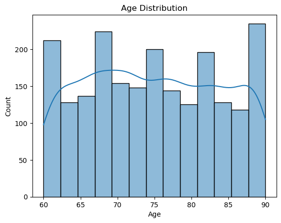

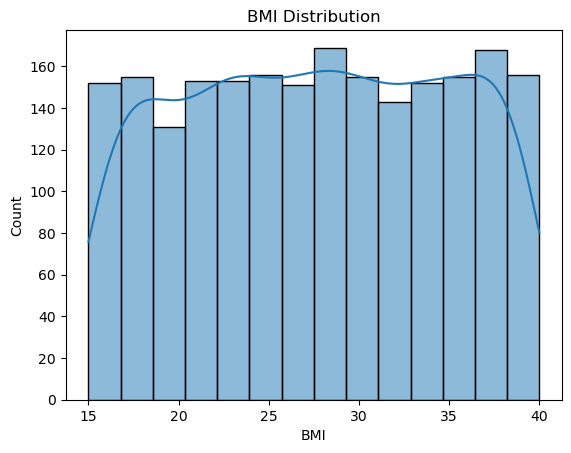

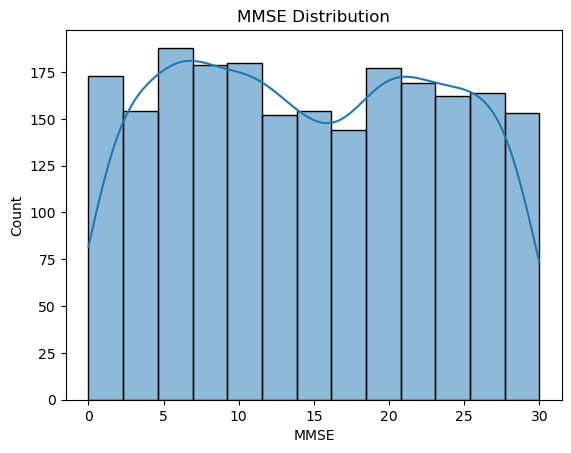

```python
#Plot distributions
import seaborn as sns
import matplotlib.pyplot as plt

sns.histplot(df['Age'], kde=True)
plt.title("Age Distribution")
plt.show()

sns.histplot(df['BMI'], kde=True)
plt.title("BMI Distribution")
plt.show()

sns.histplot(df['MMSE'], kde=True)
plt.title("MMSE Distribution")
plt.show()
```

```python
#Gender distribution check
df['Gender'].value_counts(normalize=True)
```

```
Gender
1    0.506282
0    0.493718
Name: proportion, dtype: float64
```

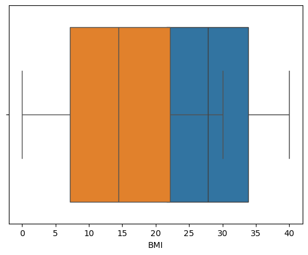

```python
#Boxplot for outlier detection
sns.boxplot(x=df['BMI'])
sns.boxplot(x=df['MMSE'])
```

### Analysis 4:

```python
#Investigate the target variable
df['Diagnosis'].value_counts(normalize=True)
```

```
Diagnosis
0    0.646347
1    0.353653
Name: proportion, dtype: float64
```

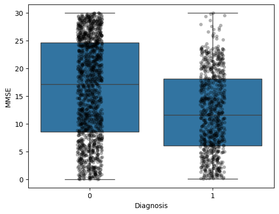

```python
#plot MMSE vs Diagnosis as this might be a relevant variable for Diagnosis prediction
sns.boxplot(x='Diagnosis', y='MMSE', data=df)
sns.stripplot(x='Diagnosis', y='MMSE', data=df, color='black', alpha=0.3)
```

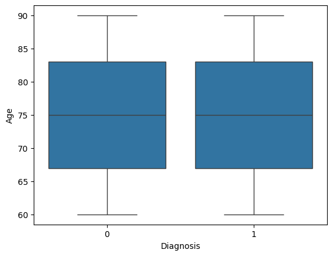

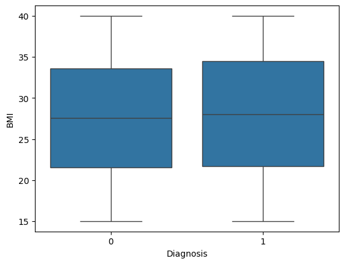

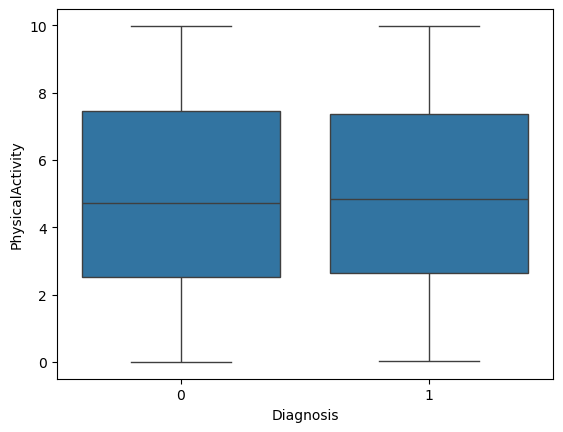

```python
#check some other variables for potential predictive strength
sns.boxplot(x='Diagnosis', y='Age', data=df)
plt.show()

sns.boxplot(x='Diagnosis', y='BMI', data=df)
plt.show()

sns.boxplot(x='Diagnosis', y='PhysicalActivity', data=df)
plt.show()
```

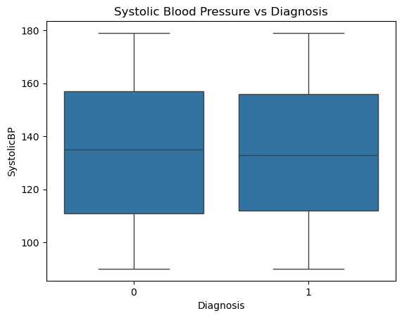

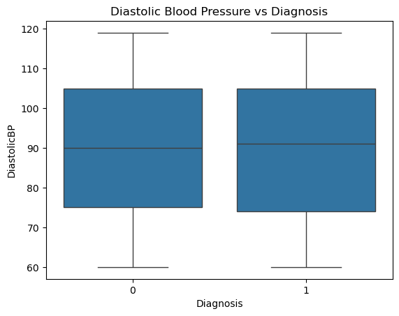

```python
#Check some of the medical variables
# Blood pressure
sns.boxplot(x='Diagnosis', y='SystolicBP', data=df)
plt.title("Systolic Blood Pressure vs Diagnosis")
plt.show()

sns.boxplot(x='Diagnosis', y='DiastolicBP', data=df)
plt.title("Diastolic Blood Pressure vs Diagnosis")
plt.show()
```

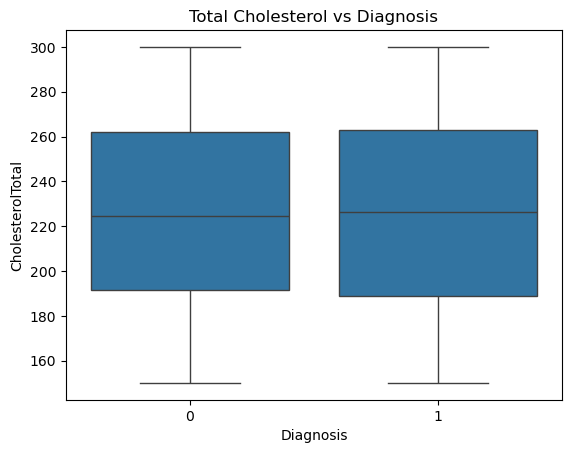

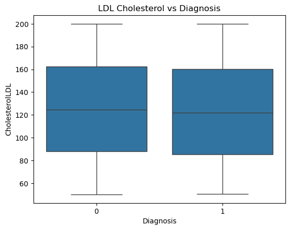

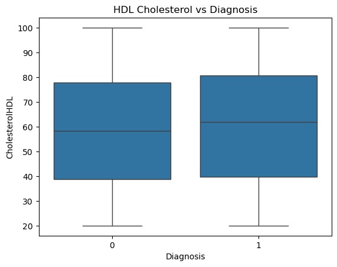

```python
#some more medical variables
# Cholesterol
sns.boxplot(x='Diagnosis', y='CholesterolTotal', data=df)
plt.title("Total Cholesterol vs Diagnosis")
plt.show()

sns.boxplot(x='Diagnosis', y='CholesterolLDL', data=df)
plt.title("LDL Cholesterol vs Diagnosis")
plt.show()

sns.boxplot(x='Diagnosis', y='CholesterolHDL', data=df)
plt.title("HDL Cholesterol vs Diagnosis")
plt.show()
```

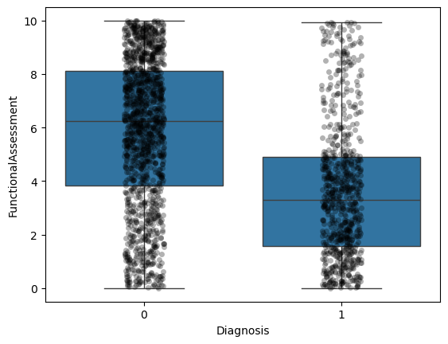

```
<function matplotlib.pyplot.show(close=None, block=None)>
```

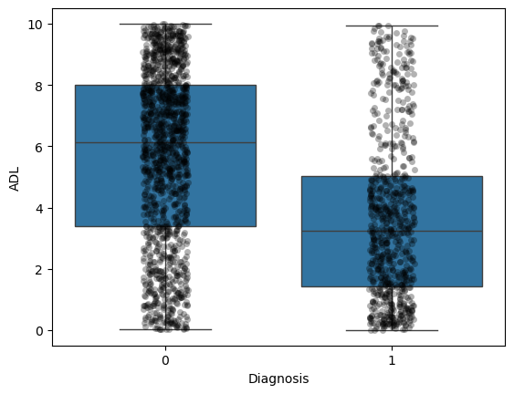

```python
# Functional / cognitive
sns.boxplot(x='Diagnosis', y='FunctionalAssessment', data=df)
sns.stripplot(x='Diagnosis', y='FunctionalAssessment', data=df, color='black', alpha=0.3)
plt.show()

sns.boxplot(x='Diagnosis', y='ADL', data=df)
sns.stripplot(x='Diagnosis', y='ADL', data=df, color='black', alpha=0.3)
plt.show
```

```python
#categorical variables vs diagnosis

print("Family History")
print(pd.crosstab(df['FamilyHistoryAlzheimers'], df['Diagnosis'], normalize='index'))

print("\nDiabetes")
print(pd.crosstab(df['Diabetes'], df['Diagnosis'], normalize='index'))

print("\nHypertension")
print(pd.crosstab(df['Hypertension'], df['Diagnosis'], normalize='index'))

print("\nSmoking")
print(pd.crosstab(df['Smoking'], df['Diagnosis'], normalize='index'))
```

```
Family History
Diagnosis                       0         1
FamilyHistoryAlzheimers
0                        0.637212  0.362788
1                        0.673432  0.326568

Diabetes
Diagnosis         0         1
Diabetes
0          0.640000  0.360000
1          0.682099  0.317901

Hypertension
Diagnosis            0         1
Hypertension
0             0.653362  0.346638
1             0.606250  0.393750

Smoking
Diagnosis         0         1
Smoking
0          0.644866  0.355134
1          0.650000  0.350000
```

**Multivariate Analysis**

```python
#check correlations with the target variable Diagnosis
df.corr()['Diagnosis'].sort_values(ascending=False)
```

```
Diagnosis                    1.000000
MemoryComplaints             0.306742
BehavioralProblems           0.224350
CholesterolHDL               0.042584
PatientID                    0.041019
Hypertension                 0.035080
CardiovascularDisease        0.031490
BMI                          0.026343
CholesterolTriglycerides     0.022672
DifficultyCompletingTasks    0.009069
DietQuality                  0.008506
CholesterolTotal             0.006394
PhysicalActivity             0.005945
DiastolicBP                  0.005293
Forgetfulness               -0.000354
Smoking                     -0.004865
Age                         -0.005488
Depression                  -0.005893
AlcoholConsumption          -0.007618
Ethnicity                   -0.014782
SystolicBP                  -0.015615
Confusion                   -0.019186
PersonalityChanges          -0.020627
Gender                      -0.020975
HeadInjury                  -0.021411
Disorientation              -0.024648
Diabetes                    -0.031508
CholesterolLDL              -0.031976
FamilyHistoryAlzheimers     -0.032900
EducationLevel              -0.043966
SleepQuality                -0.056548
MMSE                        -0.237126
ADL                         -0.332346
FunctionalAssessment        -0.364898
Name: Diagnosis, dtype: float64
```